# Finish Aligning and Generate Read Counts

Jiayi Fan

2025-03-31

The goal of this week’s homework is to complete the alignment and read count generation of all the samples of your project data. You all had a first go at it during the HW of week 6. Now is the time to get back to that, change what needs to be changed and write a script that will perform the alignment for all your samples. The final step for this week should generate a table of read counts which you should read into R.

1. Set up a github repository where you will store all your scripts, and your final report. Submit the URL of your repo. If you want to set it to private, you will have to grant us access, i.e., Luce (lskrbnek), Merv (mfansler), and Karolina (sienkie).
2. Align all your samples. Ideally use a for-loop within a script, i.e., automate and standardize the task to a certain extent, but do remember that legibility is valuable, too.
3. Generate a read count table.*
4. Load the read count table into R and perform the quality controls and processing steps that we discussed in class.

The github link for this homework is https://github.com/jiayifan-jf923/angsd-hw.

## Load Data and Normalization

```r
suppressPackageStartupMessages(library(DESeq2))
suppressPackageStartupMessages(library(tidyverse))
suppressPackageStartupMessages(library(magrittr))
suppressPackageStartupMessages(library(pheatmap))

# Set folder and read in featureCounts output
folder <- "gene_counts/"  # <--- change this to your actual path
counts_file <- paste0(folder, "fc_output")  # adjust filename if needed

df_counts <- read.table(counts_file, header = TRUE, comment.char = "#", check.names = FALSE)
head(df_counts)
```

|  | Geneid | Chr | Start | End | Strand | Length | /athena/angsd/scratch/jif4007/project/alignment/SRR27351934.star.Aligned.sortedByCoord.out.bam | /athena/angsd/scratch/jif4007/project/alignment/SRR27351933.star.Aligned.sortedByCoord.out.bam | /athena/angsd/scratch/jif4007/project/alignment/SRR27351932.star.Aligned.sortedByCoord.out.bam | /athena/angsd/scratch/jif4007/project/alignment/SRR27351931.star.Aligned.sortedByCoord.out.bam | /athena/angsd/scratch/jif4007/project/alignment/SRR27351918.star.Aligned.sortedByCoord.out.bam | /athena/angsd/scratch/jif4007/project/alignment/SRR27351917.star.Aligned.sortedByCoord.out.bam |
| --- | --- | --- | --- | --- | --- | --- | --- | --- | --- | --- | --- | --- |
| 1 | ENSG00000290825.1 | chr1;chr1;chr1 | 11869;12613;13221 | 12227;12721;14409 | +;+;+ | 1657 | 0 | 1 | 0 | 0 | 1 | 0 |
| 2 | ENSG00000223972.6 | chr1;chr1;chr1;chr1;chr1;chr1 | 12010;12179;12613;12975;13221;13453 | 12057;12227;12697;13052;13374;13670 | +;+;+;+;+;+ | 632 | 0 | 0 | 0 | 0 | 0 | 1 |
| 3 | ENSG00000227232.6 | chr1;chr1;chr1;chr1;chr1;chr1;chr1;chr1;chr1;chr1 | 14696;14970;15796;16607;16858;17233;17606;17915;18268;24738 | 14829;15038;15947;16765;17055;17368;17742;18061;18366;24886 | -;-;-;-;-;-;-;-;-;- | 1380 | 48 | 64 | 35 | 19 | 172 | 107 |
| 4 | ENSG00000278267.1 | chr1 | 17369 | 17436 | - | 68 | 2 | 4 | 1 | 1 | 5 | 5 |
| 5 | ENSG00000243485.5 | chr1;chr1;chr1;chr1;chr1 | 29554;30267;30564;30976;30976 | 30039;30667;30667;31109;31097 | +;+;+;+;+ | 1021 | 1 | 0 | 0 | 0 | 0 | 0 |
| 6 | ENSG00000284332.1 | chr1 | 30366 | 30503 | + | 138 | 0 | 0 | 0 | 0 | 0 | 0 |

Here I loaded the read counts as tables, filter out genes with zero total counts, and normalize for sequencing depth.

```r
# Extract SRR id
colnames(df_counts) <- gsub(".*/(SRR[0-9]+).*", "\\1", colnames(df_counts))

srr_ids <- colnames(df_counts)[-(1:6)]
if (length(srr_ids) != 6) {
  stop("Expected 6 samples but found ", length(srr_ids))
}

rownames(df_counts) <- make.names(df_counts$Geneid, unique = TRUE)
cts_gene_sample <- df_counts[, srr_ids]

sample_conditions <- c("shWT1", "shWT1", "shWT1_dox", "shWT1_dox", "LP9_ctrl", "LP9_ctrl")

df_coldata <- data.frame(
  condition = factor(sample_conditions),
  row.names = srr_ids
)

# Create DESeqDataSet
library(DESeq2)
dds <- DESeqDataSetFromMatrix(
  countData = cts_gene_sample,
  colData = df_coldata,
  design = ~ condition
)

rowData(dds) <- df_counts[, 1:6]

# Filter out genes with zero total counts
dds <- dds[rowSums(counts(dds)) > 0, ]

# Normalize for sequencing depth
dds <- estimateSizeFactors(dds)
print(sizeFactors(dds))
```

```
## SRR27351934 SRR27351933 SRR27351932 SRR27351931 SRR27351918 SRR27351917
##   1.0522128   0.9825932   0.5568291   0.5453254   1.9819008   1.6900255
```

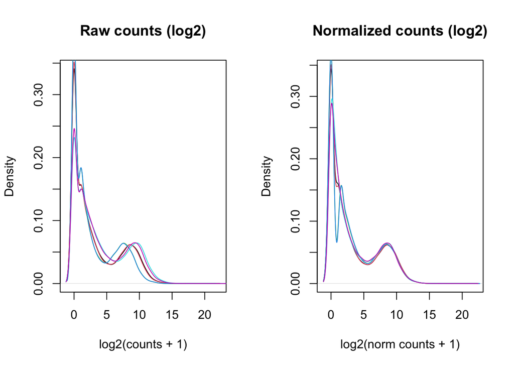

```r
# QC plot: raw vs normalized counts
par(mfrow = c(1, 2))
plot(density(log2(counts(dds)[,1] + 1)), col = 1, main = "Raw counts (log2)", xlab = "log2(counts + 1)")
for (i in 2:ncol(dds)) {
  lines(density(log2(counts(dds)[,i] + 1)), col = i)
}

plot(density(log2(counts(dds, normalized = TRUE)[,1] + 1)), col = 1, main = "Normalized counts (log2)", xlab = "log2(norm counts + 1)")
for (i in 2:ncol(dds)) {
  lines(density(log2(counts(dds, normalized = TRUE)[,i] + 1)), col = i)
}
```

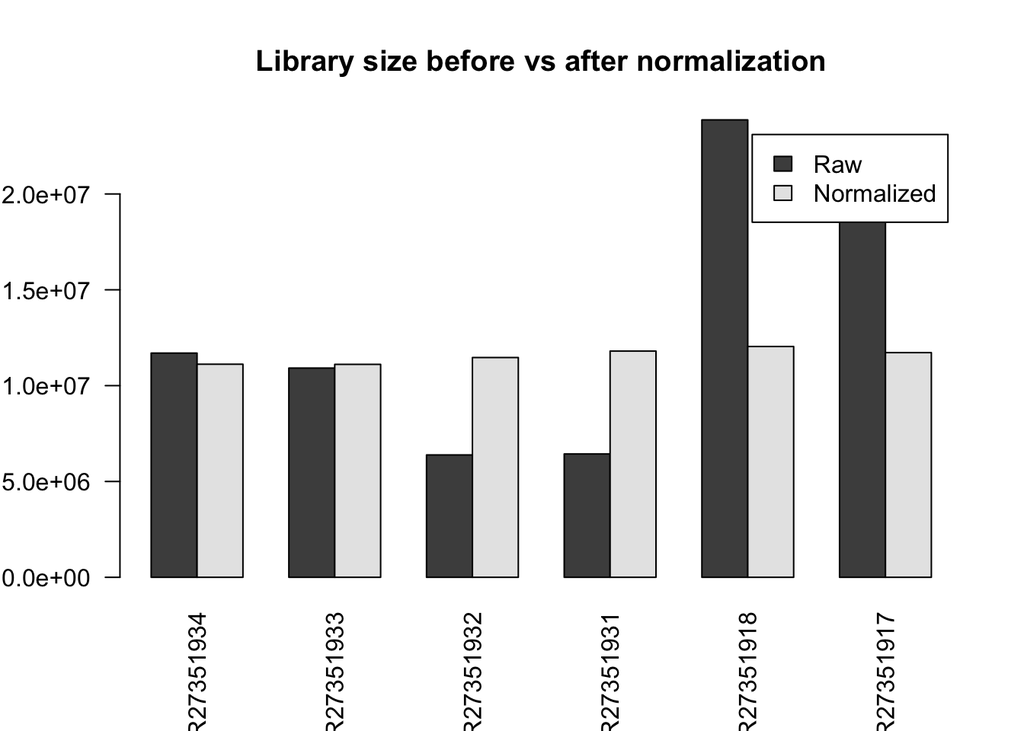

```r
raw_totals <- colSums(counts(dds))
norm_totals <- colSums(counts(dds, normalized = TRUE))

barplot(rbind(raw_totals, norm_totals), beside = TRUE,
        names.arg = colnames(dds), legend.text = c("Raw", "Normalized"),
        main = "Library size before vs after normalization", las = 2)
```

After normalization, the read count across samples are the same, so the size factor normalization worked as expected.

## Visualization (correlation heatmaps, PCA)

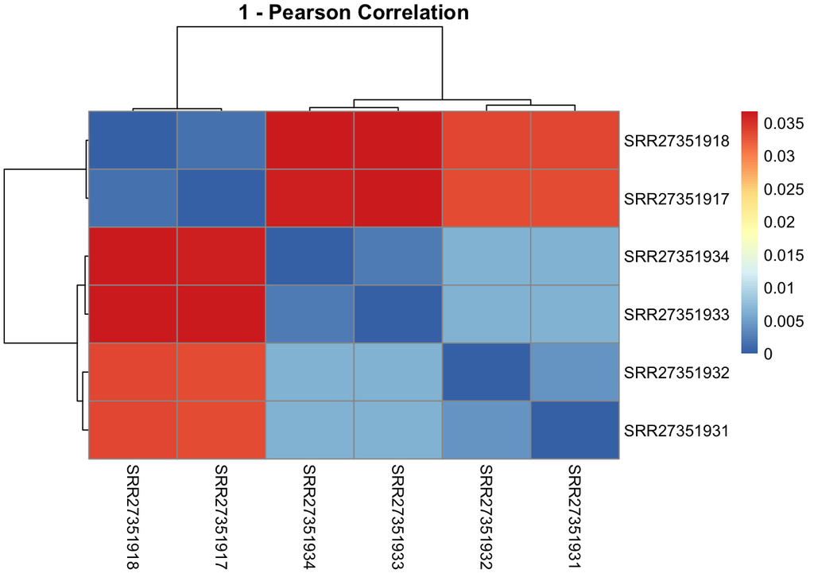

```r
# Log transformation
rlog_dds <- rlog(dds)

# Compute distance matrix
corr_matrix <- cor(assay(rlog_dds), method = "pearson")
pheatmap(1 - corr_matrix, main = "1 - Pearson Correlation")
```

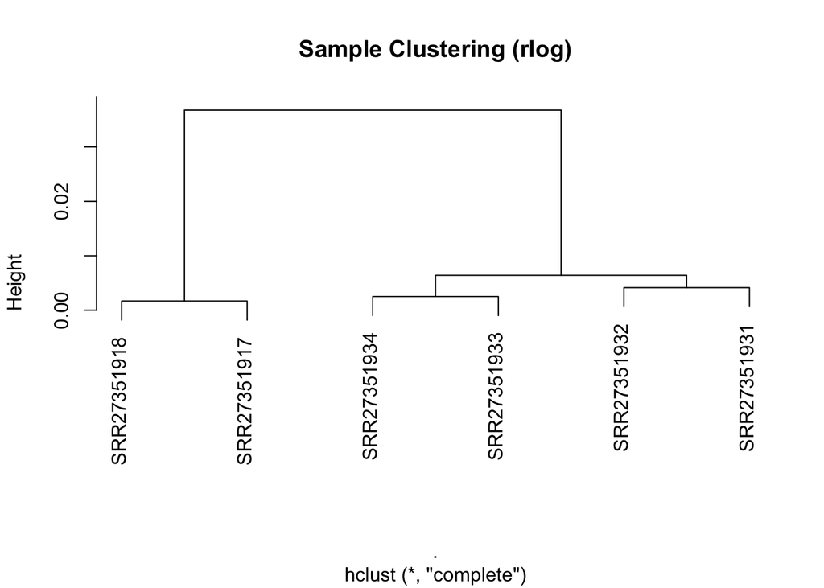

```r
# Hierarchical clustering
as.dist(1 - corr_matrix) %>%
  hclust() %>%
  plot(labels = colnames(corr_matrix), main = "Sample Clustering (rlog)")
```

```
## using ntop=500 top features by variance
```

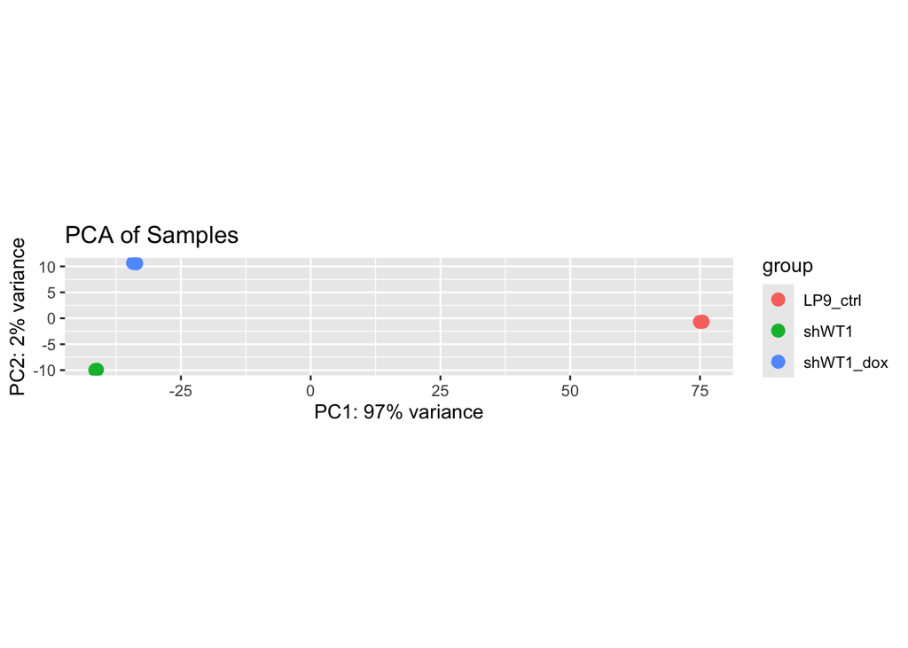

```r
# PCA plot
plotPCA(rlog_dds, intgroup = "condition") +
  ggtitle("PCA of Samples")
```

According to the PCA and clustering, there are clear separation of different conditions, and similarity within same conditions.

## Differential Expression Analysis

```r
# Ensure WT is reference level
dds$condition <- relevel(dds$condition, ref = "LP9_ctrl")

# Run DESeq2 analysis
dds <- DESeq(dds)
# Get results with adjusted p-values (FDR)
res <- results(dds, independentFiltering = TRUE, alpha = 0.05)

# Summary of results
summary(res)
```

```
##
## out of 39249 with nonzero total read count
## adjusted p-value < 0.05
## LFC > 0 (up)       : 5153, 13%
## LFC < 0 (down)     : 5455, 14%
## outliers [1]       : 0, 0%
## low counts [2]     : 16741, 43%
## (mean count < 2)
## [1] see 'cooksCutoff' argument of ?results
## [2] see 'independentFiltering' argument of ?results
```

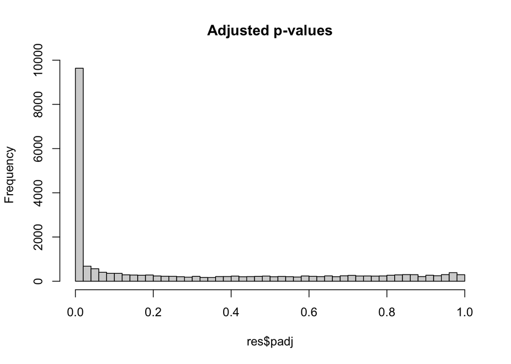

```r
# Histogram of adjusted p-values
hist(res$padj, breaks = 40, main = "Adjusted p-values")
```

```r
# Sort by significance
res_sorted <- res[order(res$padj), ]
head(res_sorted)
```

```
## log2 fold change (MLE): condition shWT1 dox vs LP9 ctrl
## Wald test p-value: condition shWT1 dox vs LP9 ctrl
## DataFrame with 6 rows and 6 columns
##                     baseMean log2FoldChange     lfcSE      stat    pvalue
##                    <numeric>      <numeric> <numeric> <numeric> <numeric>
## ENSG00000160712.13   1524.81        4.41848 0.1147990   38.4888         0
## ENSG00000143248.13   4803.92       10.59683 0.2690599   39.3847         0
## ENSG00000185630.20   2353.50        3.31007 0.0805128   41.1123         0
## ENSG00000058668.16   4020.51        3.90121 0.0703899   55.4228         0
## ENSG00000143514.18   4720.70        2.73235 0.0679190   40.2295         0
## ENSG00000116991.12   1302.29        4.78184 0.1125072   42.5025         0
##                         padj
##                    <numeric>
## ENSG00000160712.13         0
## ENSG00000143248.13         0
## ENSG00000185630.20         0
## ENSG00000058668.16         0
## ENSG00000143514.18         0
## ENSG00000116991.12         0
```

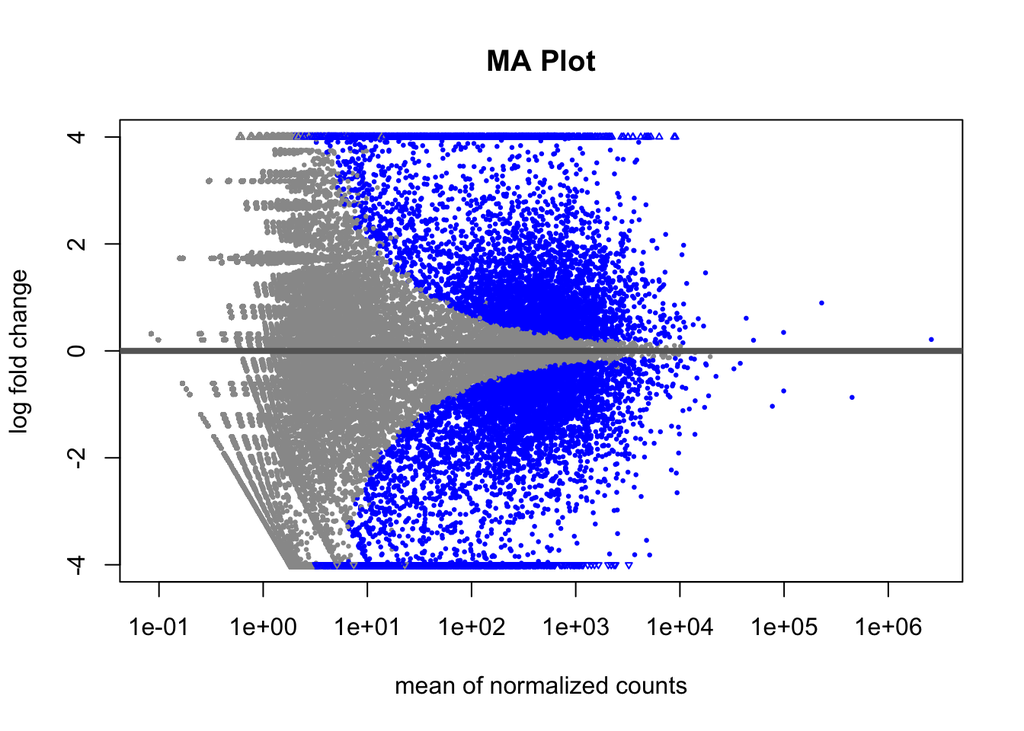

```r
# MA plot (log2FC vs mean normalized counts)
plotMA(res, alpha = 0.05, ylim = c(-4, 4), main = "MA Plot")
```

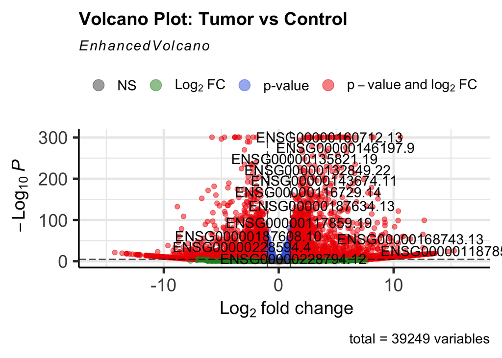

```r
# Volcano plot (requires EnhancedVolcano)
# BiocManager::install("EnhancedVolcano")
library(EnhancedVolcano)
EnhancedVolcano(res,
    lab = rownames(res),
    x = "log2FoldChange",
    y = "padj",
    title = "Volcano Plot: Tumor vs Control")
```

Select genes with adjusted p-value < 0.05 for heatmap. The ploted heatmap shows z-score-scaled expression across samples.

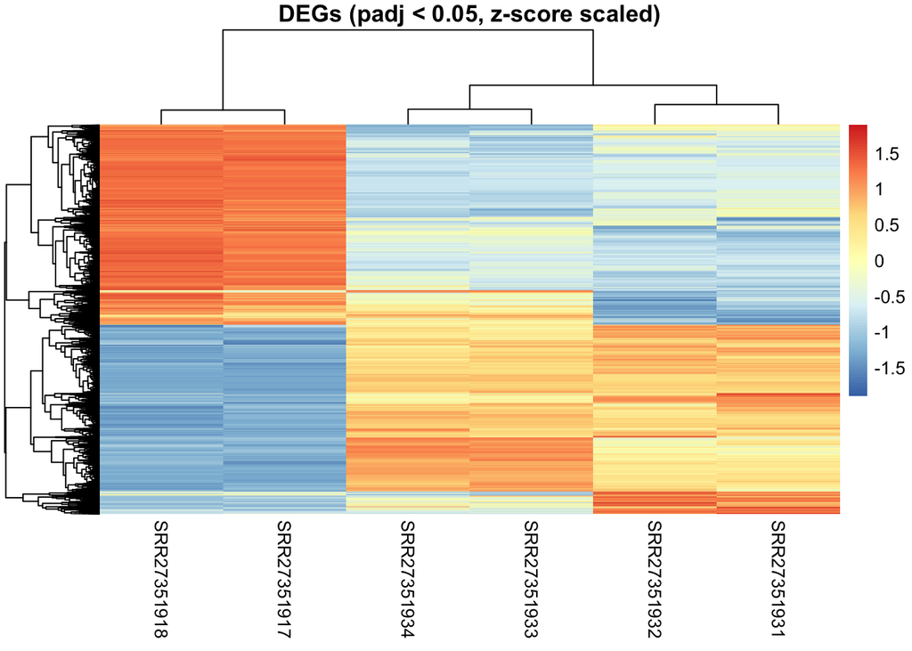

```r
library(pheatmap)

# Subset genes
sig_genes <- rownames(subset(res, padj < 0.05))
rlog_mat <- assay(rlog_dds)[sig_genes, ]

pheatmap(rlog_mat, scale = "row", show_rownames = FALSE,
         main = "DEGs (padj < 0.05, z-score scaled)")
```